# Atividade 2

### IBOV

Usamos o critério informacional para melhor fittar um modelo ARIMA. Para isso usamos a função `auto.arima()` que retorna o melhor modelo ARIMA de acordo com o valor AIC ou BIC. A função realiza uma pesquisa sobre o modelo possível dentro das restrições de ordem fornecidas. Como comparação temos que tentar usar o critério informacional com descuido gera interpretações imprecisas. Concluímos que o melhor modelo é ARIMA(1,1,0).

```r
auto.arima(ibov)
```

```
## Series: ibov
## ARIMA(0,1,2)
##
## Coefficients:
##           ma1     ma2
##       -0.0801  0.0465
## s.e.   0.0130  0.0131
##
## sigma^2 = 888347:  log likelihood = -48603.62
## AIC=97213.25   AICc=97213.25   BIC=97233.28
```

```r
auto.arima(libov,max.p=12,max.q=12,max.d=2,stepwise=FALSE,approx=FALSE)
```

```
## Series: libov
## ARIMA(1,1,0)
##
## Coefficients:
##           ar1
##       -0.0290
## s.e.   0.0131
##
## sigma^2 = 0.0002943:  log likelihood = 15559.61
## AIC=-31115.22   AICc=-31115.22   BIC=-31101.86
```

```r
auto.arima(dlibov,max.p=12,max.q=12,max.d=2,stepwise=FALSE,approx=FALSE)
```

```
## Series: dlibov
## ARIMA(1,0,0) with zero mean
##
## Coefficients:
##           ar1
##       -0.0290
## s.e.   0.0131
##
## sigma^2 = 2.943:  log likelihood = -11514.19
## AIC=23032.37   AICc=23032.37   BIC=23045.73
```

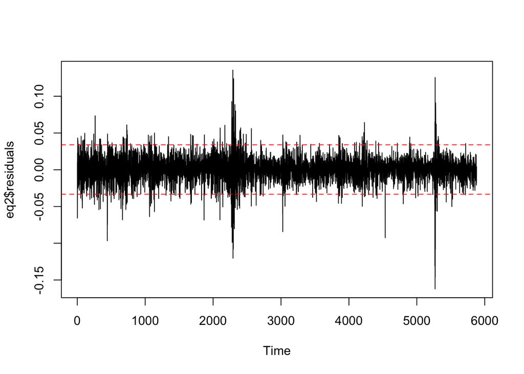

```r
eq2 <- arima(libov, order=c(1,1,1), include.mean = TRUE, method= "ML")
plot(eq2$residuals)
abline(h = mean(eq2$residuals)+1.96*sd(eq2$residuals), col='red', lty=2)
abline(h = mean(eq2$residuals)-1.96*sd(eq2$residuals), col='red', lty=2)
```

```r
jarque.bera.test(eq2$residuals)
```

```
##
##  Jarque Bera Test
##
## data:  eq2$residuals
## X-squared = 12981, df = 2, p-value < 2.2e-16
```

## Estimando Recursivamente

### BBAS3

O melhor modelo escolhido inicialmente não é possivel ser estimado por OLS. Assim vamos considerar o ARIMA(1,1,0) e estimando o modelo por OLS

```r
df_recursivo <- cbind(dlbbas,Lag(dlbbas))
colnames(df_recursivo) <- c("dlbbas", "dlbbas_lag")
eq1r <- lapply(seq(10, length(dlbbas)), function(x) lm(dlbbas ~ dlbbas_lag, data = df_recursivo[1:x, ]))
summary(eq1r[[1]])
```

```
##
## Call:
## lm(formula = dlbbas ~ dlbbas_lag, data = df_recursivo[1:x, ])
##
## Residuals:
##     Min      1Q  Median      3Q     Max
## -2.1484 -1.5255 -0.2015  0.7579  3.4312
##
## Coefficients:
##             Estimate Std. Error t value Pr(>|t|)
## (Intercept)   0.4639     0.6217   0.746    0.480
## dlbbas_lag   -0.4270     0.2380  -1.794    0.116
##
## Residual standard error: 1.865 on 7 degrees of freedom
##   (1 observation deleted due to missingness)
## Multiple R-squared:  0.315,  Adjusted R-squared:  0.2171
## F-statistic: 3.219 on 1 and 7 DF,  p-value: 0.1159
```

```r
length(eq1r)
```

```
## [1] 5870
```

```r
# storing all coefficients
all_intercepts <- unlist(sapply(1:length(eq1r),function(j) eq1r[[j]]$coefficients[1]))
all_slopes<-unlist(sapply(1:length(eq1r),function(j) eq1r[[j]]$coefficients[2]))
all_slopes[1]  # slope from the first regression
```

```
## dlbbas_lag
## -0.4269905
```

```r
# storing sd
sd_intercepts <- unlist(sapply(1:length(eq1r),function(j) summary(eq1r[[j]])$coefficients[3]))
sd_slopes<-unlist(sapply(1:length(eq1r),function(j) summary(eq1r[[j]])$coefficients[4]))
sd_slopes[1]  # slope sd from the first regression
```

```
## [1] 0.2379895
```

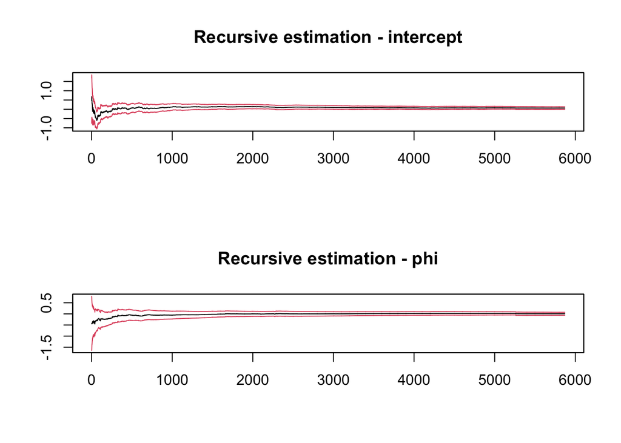

```r
# plotting the coefficients
par(mfrow = c(2,1))

plot.zoo(cbind(all_intercepts,
               all_intercepts+ sd_intercepts*1.96,
               all_intercepts-sd_intercepts*1.96),
         plot.type = "single",
         main = "Recursive estimation - intercept",
         ylab = "", xlab = "",
         col = c(1,2,2))


plot.zoo(cbind(all_slopes,
               all_slopes+ sd_intercepts*1.96,
               all_slopes-sd_intercepts*1.96),
         plot.type = "single",
         main = "Recursive estimation - phi",
         ylab = "", xlab = "",
         col = c(1,2,2))
```

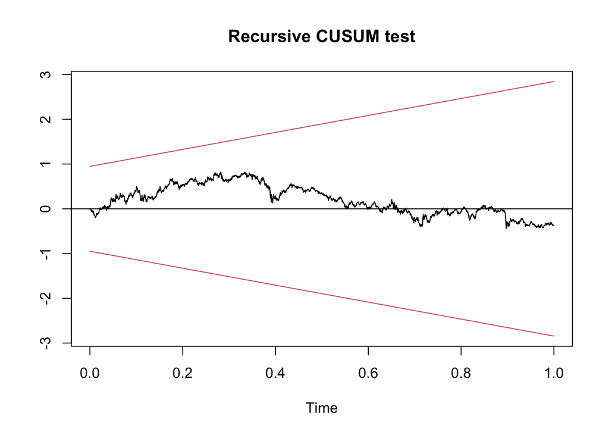

```r
# CUSUM
cusum <- strucchange::efp(dlbbas ~ Lag(dlbbas), type = "Rec-CUSUM")
plot(cusum, ylab = "")
```

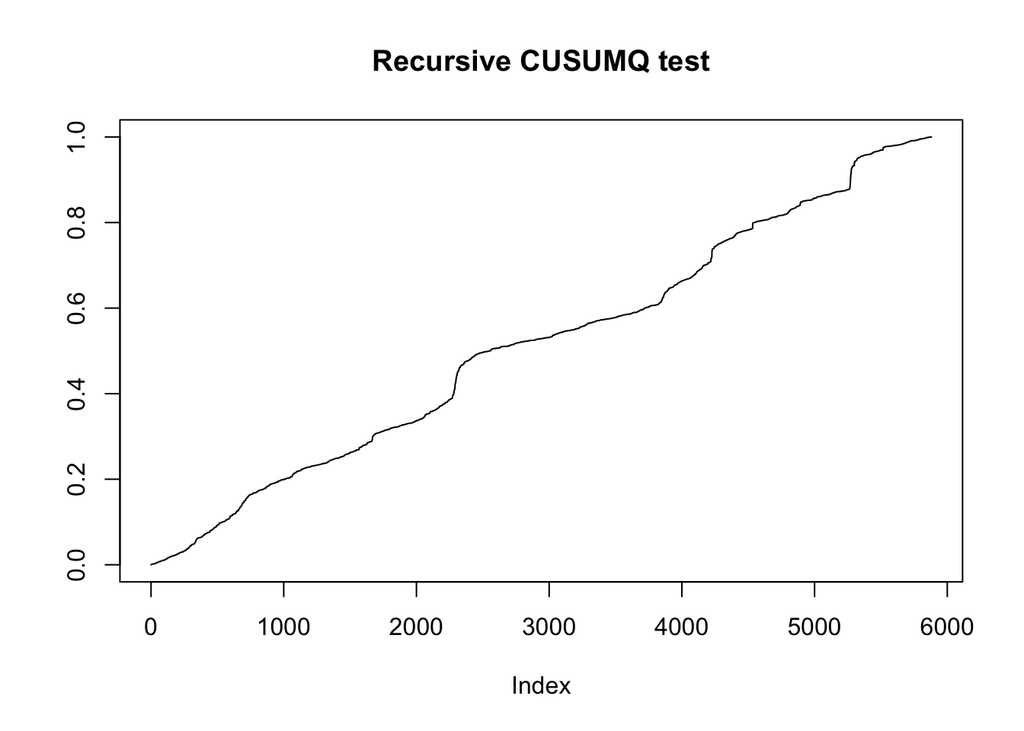

```r
# CUSUMQ
residrls2 <- eq1$residuals^2
cusumq <- cumsum(c(0, residrls2))/sum(residrls2)
plot(cusumq, type = "l", main = "Recursive CUSUMQ test", ylab = "")
```

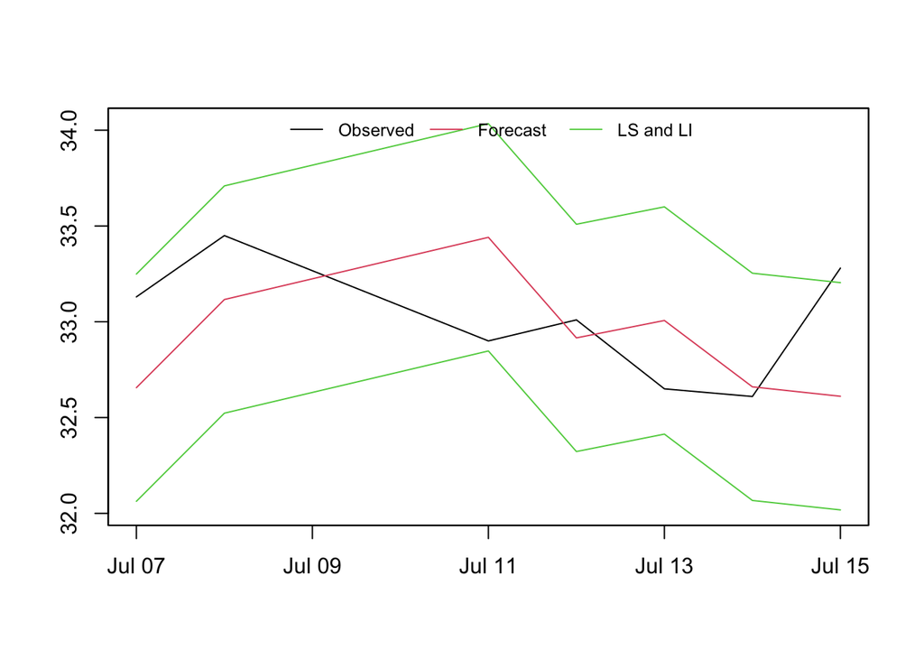

```r
# Prediction of Dollar
bbas_ff <- c()
h <- 7
for(i in 0:(h-1)){
  eq1 <- Arima(bbas[1:(length(bbas)-h+i),], order = c(1,1,0))
  aux_eq1_f <- forecast(eq1, h = 1)$mean
  bbas_ff <- rbind(bbas_ff, aux_eq1_f)
}


bbas_f <- bbas[(length(bbas)-(h-1)):length(bbas)]

par(mfrow=c(1,1))
plot.zoo(cbind(bbas_f, bbas_ff,
               bbas_ff + 1.96*sd(bbas_ff),
               bbas_ff - 1.96*sd(bbas_ff)),
         plot.type = "single",
         col = c(1,2,3,3),
         ylab = "",
         xlab = "",
)
legend("top", inset=c(0,0),  horiz=TRUE, cex = .8,
       y.intersp = 1, lty = 1, bty = "n",
       legend = c("Observed", "Forecast", "LS and LI"), col = c(1,2,3,3))
```

### IBOV

Assim vamos considerar o ARIMA(1,1,0) e estimando o modelo por OLS

```r
df_recursivo <- cbind(dlibov,Lag(dlibov))
colnames(df_recursivo) <- c("dlibov", "dlibov_lag")
eq1r <- lapply(seq(10, length(dlibov)), function(x) lm(dlibov ~ dlibov_lag, data = df_recursivo[1:x, ]))
summary(eq1r[[1]])
```

```
##
## Call:
## lm(formula = dlibov ~ dlibov_lag, data = df_recursivo[1:x, ])
##
## Residuals:
##     Min      1Q  Median      3Q     Max
## -3.3932 -1.7839 -0.3433  1.2910  2.9843
##
## Coefficients:
##             Estimate Std. Error t value Pr(>|t|)
## (Intercept)   1.5350     0.7730   1.986   0.0874 .
## dlibov_lag   -0.1919     0.2347  -0.818   0.4405
## ---
## Signif. codes:  0 '***' 0.001 '**' 0.01 '*' 0.05 '.' 0.1 ' ' 1
##
## Residual standard error: 2.296 on 7 degrees of freedom
##   (1 observation deleted due to missingness)
## Multiple R-squared:  0.08718,    Adjusted R-squared:  -0.04322
## F-statistic: 0.6686 on 1 and 7 DF,  p-value: 0.4405
```

```r
length(eq1r)
```

```
## [1] 5870
```

```r
# storing all coefficients
all_intercepts <- unlist(sapply(1:length(eq1r),function(j) eq1r[[j]]$coefficients[1]))
all_slopes<-unlist(sapply(1:length(eq1r),function(j) eq1r[[j]]$coefficients[2]))
all_slopes[1]  # slope from the first regression
```

```
## dlibov_lag
## -0.1918747
```

```r
# storing sd
sd_intercepts <- unlist(sapply(1:length(eq1r),function(j) summary(eq1r[[j]])$coefficients[3]))
sd_slopes<-unlist(sapply(1:length(eq1r),function(j) summary(eq1r[[j]])$coefficients[4]))
sd_slopes[1]  # slope sd from the first regression
```

```
## [1] 0.2346648
```

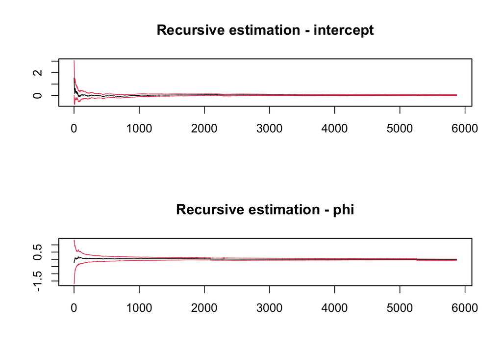

```r
# plotting the coefficients
par(mfrow = c(2,1))

plot.zoo(cbind(all_intercepts,
               all_intercepts+ sd_intercepts*1.96,
               all_intercepts-sd_intercepts*1.96),
         plot.type = "single",
         main = "Recursive estimation - intercept",
         ylab = "", xlab = "",
         col = c(1,2,2))


plot.zoo(cbind(all_slopes,
               all_slopes+ sd_intercepts*1.96,
               all_slopes-sd_intercepts*1.96),
         plot.type = "single",
         main = "Recursive estimation - phi",
         ylab = "", xlab = "",
         col = c(1,2,2))
```

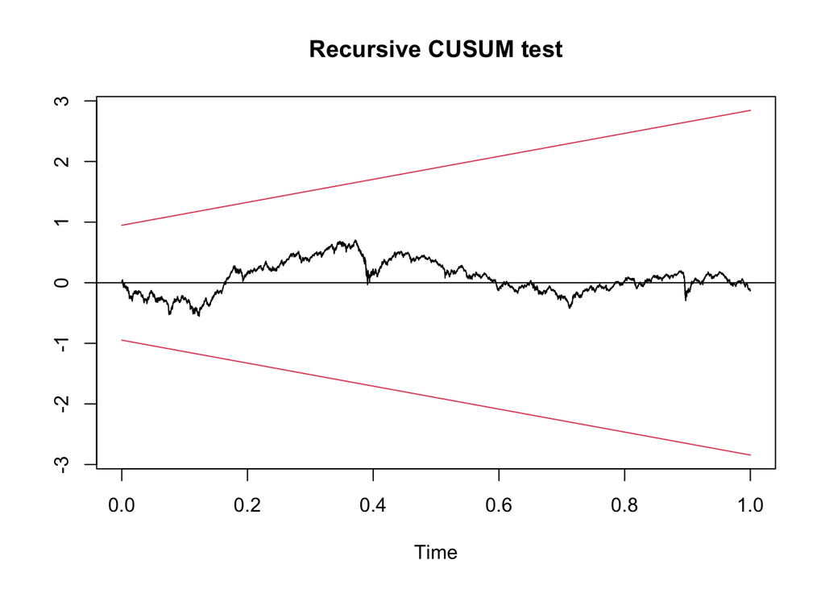

```r
# CUSUM
cusum <- strucchange::efp(dlibov ~ Lag(dlibov), type = "Rec-CUSUM")
plot(cusum, ylab = "")
```

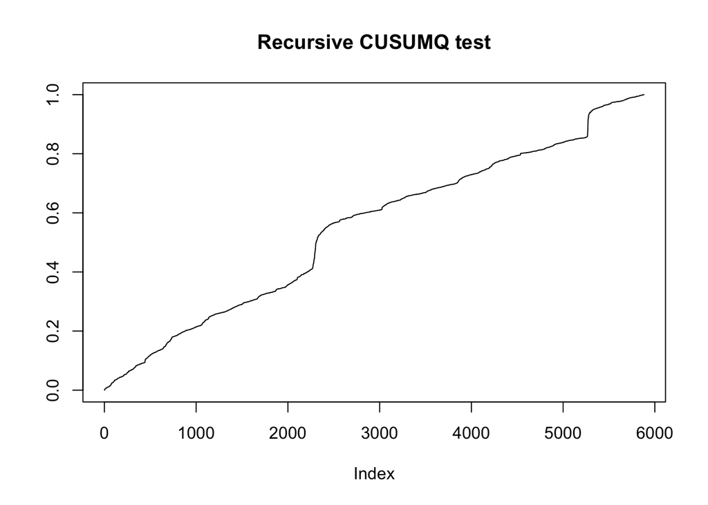

```r
# CUSUMQ
residrls2 <- eq2$residuals^2
cusumq <- cumsum(c(0, residrls2))/sum(residrls2)
plot(cusumq, type = "l", main = "Recursive CUSUMQ test", ylab = "")
```

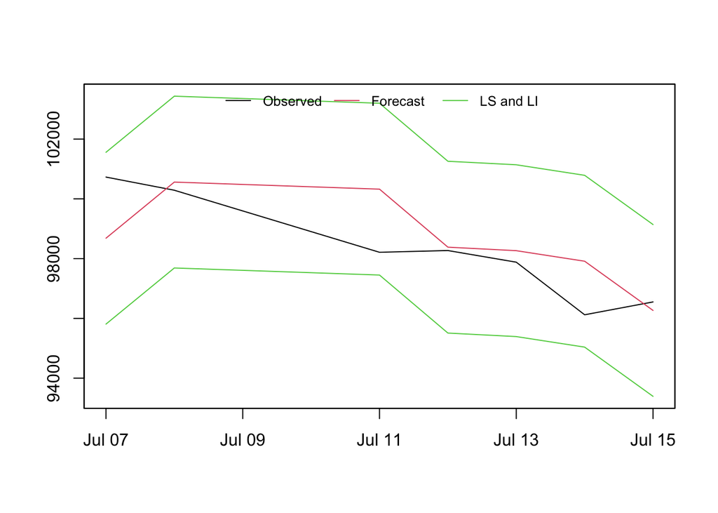

```r
ibov_ff <- c()
h <- 7
for(i in 0:(h-1)){
  eq1 <- Arima(ibov[1:(length(ibov)-h+i),], order = c(1,1,0))
  aux_eq1_f <- forecast(eq1, h = 1)$mean
  ibov_ff <- rbind(ibov_ff, aux_eq1_f)
}


ibov_f <- ibov[(length(ibov)-(h-1)):length(ibov)]

par(mfrow=c(1,1))
plot.zoo(cbind(ibov_f, ibov_ff,
               ibov_ff + 1.96*sd(ibov_ff),
               ibov_ff - 1.96*sd(ibov_ff)),
         plot.type = "single",
         col = c(1,2,3,3),
         ylab = "",
         xlab = "",
)
legend("top", inset=c(0,0),  horiz=TRUE, cex = .8,
       y.intersp = 1, lty = 1, bty = "n",
       legend = c("Observed", "Forecast", "LS and LI"), col = c(1,2,3,3))
```